# Session 07: Factors, Dates and Times, and Vectors

326.212 전산통계 및 실습

# Prerequisite

```r
library(tidyverse)
library(forcats)   # Package for dealing with factors
library(lubridate) # Package for dealing with dates and times
```

# Factors

Recall that **factor = categorical variables**. `forcats` package contains helpers for manipulating factors.

- reordering factor levels
  - moving specified levels to front
  - ordering by first appearance
  - reversing
  - randomly shuffling
- modifying factor levels
  - collapsing rare levels into other
  - ‘anonymising’
  - manually ‘recoding’

## Reordering levels

Two functions covered in class:

- `fct_relevel`: Reordering by hand.
- `fct_reorder`: Reordering by sorting along another variable.

```r
gss_cat$relig %>% levels()
```

```
##  [1] "No answer"               "Don't know"
##  [3] "Inter-nondenominational" "Native american"
##  [5] "Christian"               "Orthodox-christian"
##  [7] "Moslem/islam"            "Other eastern"
##  [9] "Hinduism"                "Buddhism"
## [11] "Other"                   "None"
## [13] "Jewish"                  "Catholic"
## [15] "Protestant"              "Not applicable"
```

```r
gss_cat$relig %>%
  fct_reorder(gss_cat$tvhours, function(x) mean(x, na.rm = TRUE), .desc = TRUE) %>%
  levels()
```

```
##  [1] "Don't know"              "Native american"
##  [3] "Protestant"              "Catholic"
##  [5] "Inter-nondenominational" "Christian"
##  [7] "Other"                   "No answer"
##  [9] "None"                    "Jewish"
## [11] "Moslem/islam"            "Orthodox-christian"
## [13] "Buddhism"                "Hinduism"
## [15] "Other eastern"           "Not applicable"
```

```r
gss_cat$relig %>%
  fct_relevel(c("Not applicable", "None")) %>%
  levels()
```

```
##  [1] "Not applicable"          "None"
##  [3] "No answer"               "Don't know"
##  [5] "Inter-nondenominational" "Native american"
##  [7] "Christian"               "Orthodox-christian"
##  [9] "Moslem/islam"            "Other eastern"
## [11] "Hinduism"                "Buddhism"
## [13] "Other"                   "Jewish"
## [15] "Catholic"                "Protestant"
```

## Modifying levels

Three functions covered in class:

- `fct_recode`: Modifying by hand.
- `fct_collapse`: Collapse levels into manually defined groups.
- `fct_lump`: Lump together least (or most) common factor levels into `"other"`.

```r
gss_cat$partyid %>% table()
```

```
## .
##          No answer         Don't know        Other party
##                154                  1                393
##  Strong republican Not str republican       Ind,near rep
##               2314               3032               1791
##        Independent       Ind,near dem   Not str democrat
##               4119               2499               3690
##    Strong democrat
##               3490
```

```r
gss_cat$partyid %>%
  fct_recode(
    "Republican, strong" = "Strong republican",
    "Republican, weak" = "Not str republican",
    "Independent, near rep" = "Ind,near rep",
    "Independent, near dem" = "Ind,near dem",
    "Democrat, weak" = "Not str democrat",
    "Democrat, strong" = "Strong democrat",
    "Other" = "Don't know",
    "Other" = "No answer",
    "Other" = "Other party") %>%
  fct_collapse(
    "Rep" = c("Republican, strong", "Republican, weak"),
    "Ind" = c("Independent", "Independent, near rep", "Independent, near dem"),
    "Dem" = c("Democrat, strong", "Democrat, weak")) %>%
  table
```

```
## .
## Other   Rep   Ind   Dem
##   548  5346  8409  7180
```

```r
gss_cat$relig %>% table
```

```
## .
##               No answer              Don't know Inter-nondenominational
##                      93                      15                     109
##         Native american               Christian      Orthodox-christian
##                      23                     689                      95
##            Moslem/islam           Other eastern                Hinduism
##                     104                      32                      71
##                Buddhism                   Other                    None
##                     147                     224                    3523
##                  Jewish                Catholic              Protestant
##                     388                    5124                   10846
##          Not applicable
##                       0
```

```r
gss_cat$relig %>% fct_lump(n = 10) %>% table
```

```
## .
## Inter-nondenominational               Christian      Orthodox-christian
##                     109                     689                      95
##            Moslem/islam                Buddhism                    None
##                     104                     147                    3523
##                  Jewish                Catholic              Protestant
##                     388                    5124                   10846
##                   Other
##                     458
```

# Dates and Times

Almost every programming languages has three data types for denoting dates and/or times:

- **Date** *e.g.*, `2017-11-28`.
- **Time** *e.g.*, `00:01:25`.
- **Date-time** *e.g.*, `2017-11-28 00:01:25 KST`.

`lubridate` package ([cheatsheet](https://github.com/rstudio/cheatsheets/raw/master/lubridate.pdf)) contains functions to work with date-times and time-spans.

- fast and user friendly parsing of date-time data
- extraction and updating of components of a date-time
  - *e.g.* years, months, days, hours, minutes, and seconds
- algebraic manipulation on date-time and time-span objects.

## Create Date / Time / Date-time

- `make_datetime`, `make_date`.
- `as_datetime`, `as_date`.

### Parse From String

Recall that **Date / Time / Date-time != String**. Actually, the date-time is the number of seconds that have elapsed since 1970-01-01 00:00:00 UTC.

Nomenclature of string parsers in `lubridate` package:

- Date part. **y**: year, **m**: month, **d**: day.
- Time part. **h**: hour, **m**: minute, **s**: second.
- Optional separator between date and time: _ (underscore)
- Accepts a wide variety of input formats.

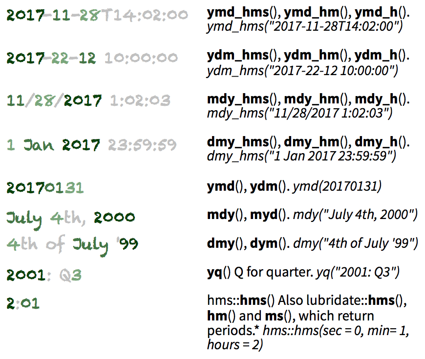

List of `lubridate` parsers

Remarks:

- Some combinations are not implemented; *e.g.* `mhs` and `ymd_ms`
- Each part accepts a wide variety of formats.

## Getting / Setting Components

There are various accessors including `year`, `month`, `mday`, `yday`, `wday`, and many others.

```r
x <- ymd_hms("2014년 11월 12일 06:00:00", tz = "Asia/Seoul")  # tz: Timezone; default is UTC.
date(x); day(x); hour(x)
```

```
## [1] "2014-11-12"
```

```
## [1] 12
```

```
## [1] 6
```

```r
hour(x) <- 20; x
```

```
## [1] "2014-11-12 20:00:00 KST"
```

## Arithmetics

Three concepts:

- Periods
- Durations
- Intervals

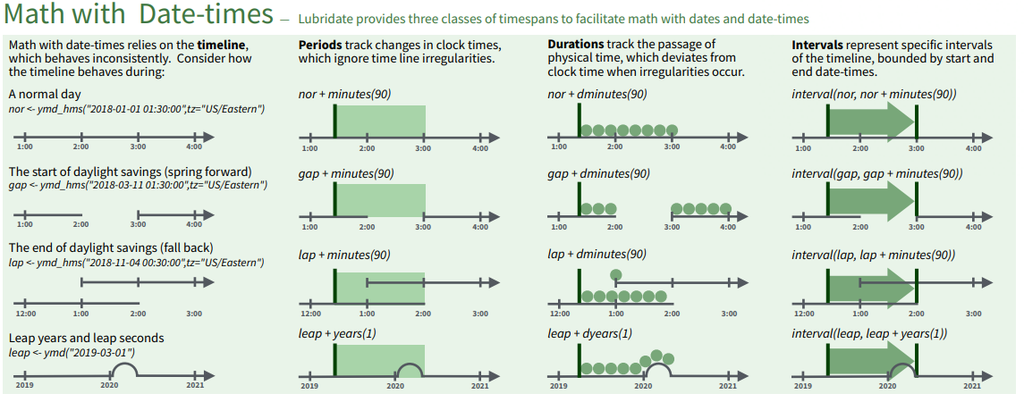

```r
nor <- ymd_hms("2018-01-01 01:30:00", tz = "US/Eastern")  # Normal day
gap <- ymd_hms("2018-03-11 01:30:00", tz = "US/Eastern")  # Begin summertime
lap <- ymd_hms("2018-11-04 00:30:00", tz = "US/Eastern")  # End summertime

nor + minutes(90); gap + minutes(90); lap + minutes(90)
```

```
## [1] "2018-01-01 03:00:00 EST"
```

```
## [1] "2018-03-11 03:00:00 EDT"
```

```
## [1] "2018-11-04 02:00:00 EST"
```

```r
nor + dminutes(90); gap + dminutes(90); lap + dminutes(90)
```

```
## [1] "2018-01-01 03:00:00 EST"
```

```
## [1] "2018-03-11 04:00:00 EDT"
```

```
## [1] "2018-11-04 01:00:00 EST"
```

```r
interval(nor, nor + minutes(90)); interval(gap, gap + minutes(90)); interval(lap, lap + minutes(90))
```

```
## [1] 2018-01-01 01:30:00 EST--2018-01-01 03:00:00 EST
```

```
## [1] 2018-03-11 01:30:00 EST--2018-03-11 03:00:00 EDT
```

```
## [1] 2018-11-04 00:30:00 EDT--2018-11-04 02:00:00 EST
```

# Vectors

## Integer vs Double

```r
typeof(1)
```

```
## [1] "double"
```

```r
typeof(1L)
```

```
## [1] "integer"
```

```r
typeof(1.5L)
```

```
## [1] "double"
```

```r
as.integer(1.6)
```

```
## [1] 1
```

## Finite precision

https://en.wikipedia.org/wiki/Floating-point_arithmetic

```r
(x <- sqrt(2) ^ 2)
```

```
## [1] 2
```

```r
x - 2
```

```
## [1] 4.440892e-16
```

```r
x - 2 == 0
```

```
## [1] FALSE
```

```r
near(x - 2, 0)
```

```
## [1] TRUE
```

## Special values

```r
c(-1, 0, 1) / 0
```

```
## [1] -Inf  NaN  Inf
```

```r
max(c())
```

```
## [1] -Inf
```

```r
min(c())
```

```
## [1] Inf
```

```r
(x <- c(1:10, NA, Inf))
```

```
##  [1]   1   2   3   4   5   6   7   8   9  10  NA Inf
```

```r
range(x, na.rm=TRUE)
```

```
## [1]   1 Inf
```

```r
range(x, na.rm=TRUE, finite=TRUE)
```

```
## [1]  1 10
```

## Vector containing multiple types

```r
typeof(c(TRUE, 2L))
```

```
## [1] "integer"
```

```r
typeof(c(1L, 1.5))
```

```
## [1] "double"
```

```r
typeof(c(1.5, "a"))
```

```
## [1] "character"
```

## Recycling rules

```r
sample(10) + 100
```

```
##  [1] 107 102 104 110 109 101 103 108 106 105
```

```r
1:10 + 1:2
```

```
##  [1]  2  4  4  6  6  8  8 10 10 12
```

```r
tibble(x = 1:4, y = 1:2)
```

```
## Tibble columns must have consistent lengths, only values of length one are recycled:
## * Length 2: Column `y`
## * Length 4: Column `x`
```

```r
tibble(x = 1:4, y = rep(1:2, 2))
```

```
## # A tibble: 4 x 2
##       x     y
##   <int> <int>
## 1     1     1
## 2     2     2
## 3     3     1
## 4     4     2
```

```r
tibble(x = 1:4, y = rep(1:2, each = 2))
```

```
## # A tibble: 4 x 2
##       x     y
##   <int> <int>
## 1     1     1
## 2     2     1
## 3     3     2
## 4     4     2
```

```r
tibble(x=1:4, y=1)
```

```
## # A tibble: 4 x 2
##       x     y
##   <int> <dbl>
## 1     1     1
## 2     2     1
## 3     3     1
## 4     4     1
```

**Acknowledgment** All contents in this note is based on the book “R for Data Science”, written by Grolemund & Wickham.